# MetaVolcanoR: Updated Features and Enrichment Analysis

Izabela Mamede, Bárbara Marinho, Cesar Prada, Helder Nakaya

2026-07-05

> 📄 **See also:** Proteomics meta-analysis — CPTAC pan-cancer example

## Setup

```r
library(MetaVolcanoR)
library(dplyr)
library(ggplot2)

data(diffexplist)
cat("Number of datasets:", length(diffexplist), "\n")
```

```
## Number of datasets: 5
```

```r
cat("Genes per dataset:",
    paste(sapply(diffexplist, nrow), collapse = ", "), "\n")
```

```
## Genes per dataset: 6573, 6573, 6944, 7131, 6944
```

## 1. Random Effects Model (REM)

The REM meta-analysis now uses an updated color palette and supports pseudogene filtering in labels.

### Basic REM

```r
mv_rem <- rem_mv(
  diffexp       = diffexplist,
  pcriteria     = "pvalue",
  foldchangecol = "Log2FC",
  genenamecol   = "Symbol",
  llcol         = "CI.L",
  rlcol         = "CI.R",
  metathr       = 0.01,
  jobname       = "REM_example",
  outputfolder  = tempdir(),
  draw          = "HTML"
)
```

```
##   index  Symbol   Log2FC_1     CI.L_1     CI.R_1       vi_1   Log2FC_2     CI.L_2     CI.R_2
## 1  4795   MXRA5  0.8150851  0.3109324  1.3192377 0.06616251  1.3001104  0.6603306  1.9398901
## 2  2166  COL6A6 -1.7480348 -2.5780749 -0.9179947 0.17934364 -0.8388366 -1.3578456 -0.3198277
## 3  2053   CIDEA         NA         NA         NA         NA         NA         NA         NA
## 4  7115 SULT1A4  0.9689025  0.5103475  1.4274575 0.05473571  0.7513323  0.4707021  1.0319624
## 5   130   ACACB -0.8431142 -1.4708480 -0.2153804 0.10257437 -1.1119841 -1.7417389 -0.4822293
## 6  6528 SLC27A2 -0.6782948 -0.9931027 -0.3634869 0.02579759 -1.8916655 -2.6822584 -1.1010726
##         vi_2   Log2FC_3     CI.L_3     CI.R_3        vi_3   Log2FC_4    CI.L_4     CI.R_4
## 1 0.10654886  1.1895480  0.8401301  1.5389659 0.031781777  0.2188594 -1.052230  1.4899492
## 2 0.07011930 -1.0300519 -1.4730328 -0.5870710 0.051080819 -1.3755263 -2.162453 -0.5885999
## 3         NA -1.0111528 -1.3226326 -0.6996729 0.025255027 -1.7991026 -2.918939 -0.6792665
## 4 0.02050012         NA         NA         NA          NA         NA        NA         NA
## 5 0.10323592 -0.5305046 -0.6957455 -0.3652637 0.007107599 -0.7991042 -1.457868 -0.1403403
## 6 0.16270229 -1.2126830 -1.6702908 -0.7550753 0.054509799 -1.3554403 -2.288444 -0.4224370
##        vi_4   Log2FC_5     CI.L_5     CI.R_5       vi_5 signcon ntimes randomSummary
```

[output cut: 20 more lines]

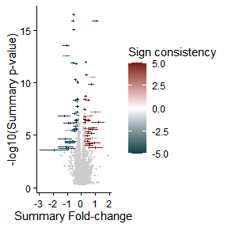

```r
mv_rem@MetaVolcano
```

### REM with labels and pseudogene filtering

When `label_top_n` is used, genes are now ranked by the topconfects `rank` metric, which balances effect size and confidence.

```r
mv_rem_labeled <- rem_mv(
  diffexp       = diffexplist,
  pcriteria     = "pvalue",
  foldchangecol = "Log2FC",
  genenamecol   = "Symbol",
  llcol         = "CI.L",
  rlcol         = "CI.R",
  metathr       = 0.01,
  label_top_n   = 10,
  label_size    = 3.5,
  plot_title    = "REM Meta-Analysis (Top 10)",
  show_legend   = TRUE,
  jobname       = "REM_labeled",
  outputfolder  = tempdir(),
  draw          = "HTML"
)
```

```
##   index  Symbol   Log2FC_1     CI.L_1     CI.R_1       vi_1   Log2FC_2     CI.L_2     CI.R_2
## 1  4795   MXRA5  0.8150851  0.3109324  1.3192377 0.06616251  1.3001104  0.6603306  1.9398901
## 2  2166  COL6A6 -1.7480348 -2.5780749 -0.9179947 0.17934364 -0.8388366 -1.3578456 -0.3198277
## 3  2053   CIDEA         NA         NA         NA         NA         NA         NA         NA
## 4  7115 SULT1A4  0.9689025  0.5103475  1.4274575 0.05473571  0.7513323  0.4707021  1.0319624
## 5   130   ACACB -0.8431142 -1.4708480 -0.2153804 0.10257437 -1.1119841 -1.7417389 -0.4822293
## 6  6528 SLC27A2 -0.6782948 -0.9931027 -0.3634869 0.02579759 -1.8916655 -2.6822584 -1.1010726
##         vi_2   Log2FC_3     CI.L_3     CI.R_3        vi_3   Log2FC_4    CI.L_4     CI.R_4
## 1 0.10654886  1.1895480  0.8401301  1.5389659 0.031781777  0.2188594 -1.052230  1.4899492
## 2 0.07011930 -1.0300519 -1.4730328 -0.5870710 0.051080819 -1.3755263 -2.162453 -0.5885999
## 3         NA -1.0111528 -1.3226326 -0.6996729 0.025255027 -1.7991026 -2.918939 -0.6792665
## 4 0.02050012         NA         NA         NA          NA         NA        NA         NA
## 5 0.10323592 -0.5305046 -0.6957455 -0.3652637 0.007107599 -0.7991042 -1.457868 -0.1403403
## 6 0.16270229 -1.2126830 -1.6702908 -0.7550753 0.054509799 -1.3554403 -2.288444 -0.4224370
##        vi_4   Log2FC_5     CI.L_5     CI.R_5       vi_5 signcon ntimes randomSummary
```

[output cut: 20 more lines]

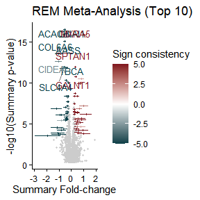

```r
mv_rem_labeled@MetaVolcano
```

### Custom colors

The `colors` parameter accepts a named vector for the sign consistency gradient:

```r
mv_rem_custom <- rem_mv(
  diffexp       = diffexplist,
  pcriteria     = "pvalue",
  foldchangecol = "Log2FC",
  genenamecol   = "Symbol",
  llcol         = "CI.L",
  rlcol         = "CI.R",
  metathr       = 0.01,
  colors        = c(low = "purple", mid = "white", high = "orange",
                    na = "gray80"),
  label_top_n   = 5,
  plot_title    = "REM with custom colors",
  jobname       = "REM_custom",
  outputfolder  = tempdir(),
  draw          = "HTML"
)
```

```
##   index  Symbol   Log2FC_1     CI.L_1     CI.R_1       vi_1   Log2FC_2     CI.L_2     CI.R_2
## 1  4795   MXRA5  0.8150851  0.3109324  1.3192377 0.06616251  1.3001104  0.6603306  1.9398901
## 2  2166  COL6A6 -1.7480348 -2.5780749 -0.9179947 0.17934364 -0.8388366 -1.3578456 -0.3198277
## 3  2053   CIDEA         NA         NA         NA         NA         NA         NA         NA
## 4  7115 SULT1A4  0.9689025  0.5103475  1.4274575 0.05473571  0.7513323  0.4707021  1.0319624
## 5   130   ACACB -0.8431142 -1.4708480 -0.2153804 0.10257437 -1.1119841 -1.7417389 -0.4822293
## 6  6528 SLC27A2 -0.6782948 -0.9931027 -0.3634869 0.02579759 -1.8916655 -2.6822584 -1.1010726
##         vi_2   Log2FC_3     CI.L_3     CI.R_3        vi_3   Log2FC_4    CI.L_4     CI.R_4
## 1 0.10654886  1.1895480  0.8401301  1.5389659 0.031781777  0.2188594 -1.052230  1.4899492
## 2 0.07011930 -1.0300519 -1.4730328 -0.5870710 0.051080819 -1.3755263 -2.162453 -0.5885999
## 3         NA -1.0111528 -1.3226326 -0.6996729 0.025255027 -1.7991026 -2.918939 -0.6792665
## 4 0.02050012         NA         NA         NA          NA         NA        NA         NA
## 5 0.10323592 -0.5305046 -0.6957455 -0.3652637 0.007107599 -0.7991042 -1.457868 -0.1403403
## 6 0.16270229 -1.2126830 -1.6702908 -0.7550753 0.054509799 -1.3554403 -2.288444 -0.4224370
##        vi_4   Log2FC_5     CI.L_5     CI.R_5       vi_5 signcon ntimes randomSummary
```

[output cut: 20 more lines]

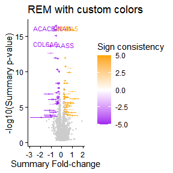

```r
mv_rem_custom@MetaVolcano
```

## 2. Forest Plots

Forest plots now accept custom colors via a named vector:

```r
# Top 3 genes by rank
top3 <- mv_rem@metaresult %>%
  filter(!is.na(randomP)) %>%
  arrange(rank) %>%
  head(3) %>%
  pull(Symbol)

cat("Top 3 genes:", paste(top3, collapse = ", "), "\n")
```

```
## Top 3 genes: MXRA5, COL6A6, CIDEA
```

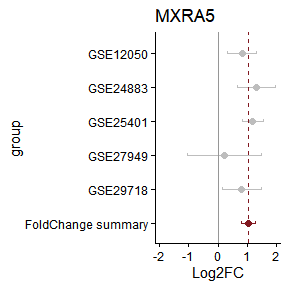

```r
# Forest plot with default updated colors
draw_forest(
  remres        = mv_rem,
  gene          = top3[1],
  genecol       = "Symbol",
  foldchangecol = "Log2FC",
  llcol         = "CI.L",
  rlcol         = "CI.R",
  jobname       = "Forest_example",
  outputfolder  = tempdir(),
  draw          = "HTML"
)
```

Custom forest plot colors:

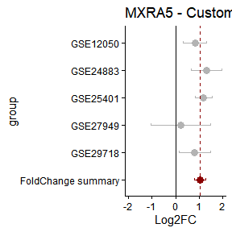

```r
draw_forest(
  remres        = mv_rem,
  gene          = top3[1],
  genecol       = "Symbol",
  foldchangecol = "Log2FC",
  llcol         = "CI.L",
  rlcol         = "CI.R",
  colors        = c(positive = "darkred", negative = "steelblue",
                    neutral = "gray70", reference = "black"),
  point_size    = 3,
  plot_title    = paste(top3[1], "- Custom colors"),
  jobname       = "Forest_custom",
  outputfolder  = tempdir(),
  draw          = "HTML"
)
```

## 3. Vote-Counting

### Fixed axis and improved labels

The vote-counting plot now uses `scale_x_continuous` for correct symmetric axis display. Labels are selected using `abs(idx)` — the package’s own combined metric of frequency and direction consistency (`idx = ndeg × ddeg`).

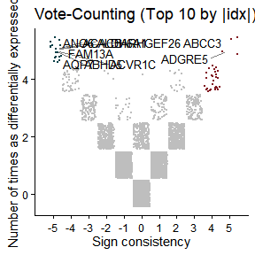

```r
mv_vote <- votecount_mv(
  diffexp       = diffexplist,
  pcriteria     = "pvalue",
  foldchangecol = "Log2FC",
  genenamecol   = "Symbol",
  geneidcol     = NULL,
  pvalue        = 0.05,
  foldchange    = 0,
  metathr       = 0.01,
  label_top_n   = 10,
  label_size    = 3.5,
  plot_title    = "Vote-Counting (Top 10 by |idx|)",
  jobname       = "Vote_example",
  outputfolder  = tempdir(),
  draw          = "HTML"
)

mv_vote@MetaVolcano
```

### Label selection criteria

Previous behavior ranked labels by `ndeg` only (number of studies where DE). This could label genes with inconsistent direction across studies.

The updated behavior uses `abs(idx)` and filters out unperturbed genes:

[output not shown]

### DEG barplot with custom colors

`draw_degbar()` now accepts a `colors` parameter:

[figure not shown]

```r
mv_vote@degfreq
```

## 4. Combining (Fisher’s Method)

Fisher’s combining approach also supports the updated color palette:

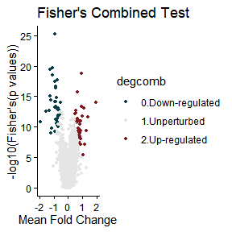

```r
mv_fisher <- combining_mv(
  diffexp       = diffexplist,
  pcriteria     = "pvalue",
  foldchangecol = "Log2FC",
  genenamecol   = "Symbol",
  metafc        = "Mean",
  metathr       = 0.01,
  colors        = c("#083e46", "gray90", "#811820"),
  point_size    = 1.2,
  show_legend   = TRUE,
  plot_title    = "Fisher's Combined Test",
  jobname       = "Fisher_example",
  outputfolder  = tempdir(),
  draw          = "HTML"
)

mv_fisher@MetaVolcano
```

## 5. Functional Enrichment — `enrichment_mv()`

The new `enrichment_mv()` function wraps fGSEA and integrates directly with the REM MetaVolcano results. Gene sets can be provided manually or downloaded automatically from MSigDB.

### Automatic MSigDB download

```r
# GO Biological Process (default: category = "C5")
enrich <- enrichment_mv(mv_rem, subcategory = "GO:BP")
enrich$plot
head(enrich$result)
```

### Three ranking strategies

```r
# 1. Fold-change — prioritizes effect size
enrich_fc <- enrichment_mv(mv_rem, ranking = "fc")

# 2. Signed significance — prioritizes statistical confidence
enrich_sp <- enrichment_mv(mv_rem, ranking = "signed_p")

# 3. Weighted FC — balances both
enrich_wfc <- enrichment_mv(mv_rem, ranking = "weighted_fc")
```

| Ranking | Formula | Best for |
| --- | --- | --- |
| `fc` | randomSummary | Pathways with large effects |
| `signed_p` | -log10(p) × sign(FC) | Pathways with consistent significance |
| `weighted_fc` | FC × -log10(p) | Balanced detection |

### Selecting pathway databases

```r
# KEGG pathways
enrich_kegg <- enrichment_mv(
  mv_rem,
  category    = "C2",
  subcategory = "CP:KEGG",
  ranking     = "weighted_fc"
)

# Hallmark gene sets
enrich_hall <- enrichment_mv(
  mv_rem,
  category = "H"
)

# GO Molecular Function only
enrich_mf <- enrichment_mv(
  mv_rem,
  subcategory = "GO:MF"
)
```

### Full customization

```r
enrich <- enrichment_mv(
  mv_rem,
  category            = "C5",
  subcategory         = "GO:BP",
  ranking             = "weighted_fc",
  plot_padj           = 0.05,
  plot_top_n          = 20,
  clean_pathway_names = TRUE,
  colors              = c(down = "navy", up = "darkred"),
  plot_title          = "GO:BP Enrichment (weighted FC ranking)"
)

enrich$plot
```

### Using custom gene sets

```r
my_pathways <- list(
  "INFLAMMATION"  = c("IL6", "TNF", "IL1B", "CXCL8", "CCL2"),
  "ANGIOGENESIS"  = c("VEGFA", "FLT1", "KDR", "ANGPT1"),
  "ECM_REMODEL"   = c("MMP2", "MMP9", "MMP12", "COL1A1")
)

enrich_custom <- enrichment_mv(
  mv_rem,
  pathways            = my_pathways,
  clean_pathway_names = FALSE
)
```